# Attrition RMD

### Checking model results aginst graphical analysis

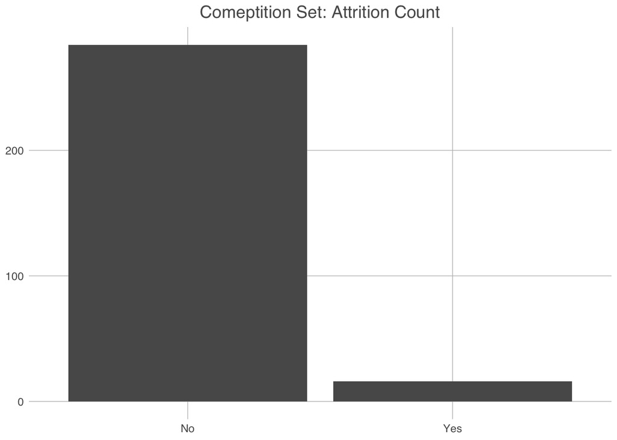

```r
CompSetResult %>% ggplot(mapping = aes(x = Attrition)) + geom_bar() + ggtitle("Comeptition Set: Attrition Count") + theme_excel_new()
```

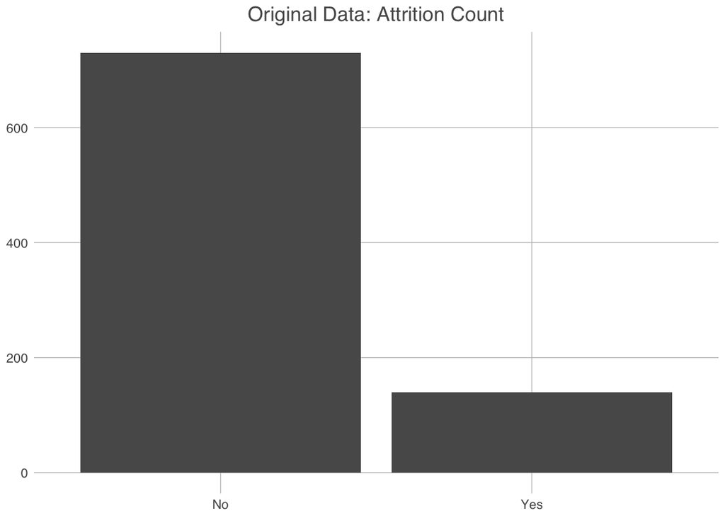

```r
dfTrain %>% ggplot(mapping = aes(x = Attrition)) + geom_bar() + ggtitle("Original Data: Attrition Count") + theme_excel_new()
```

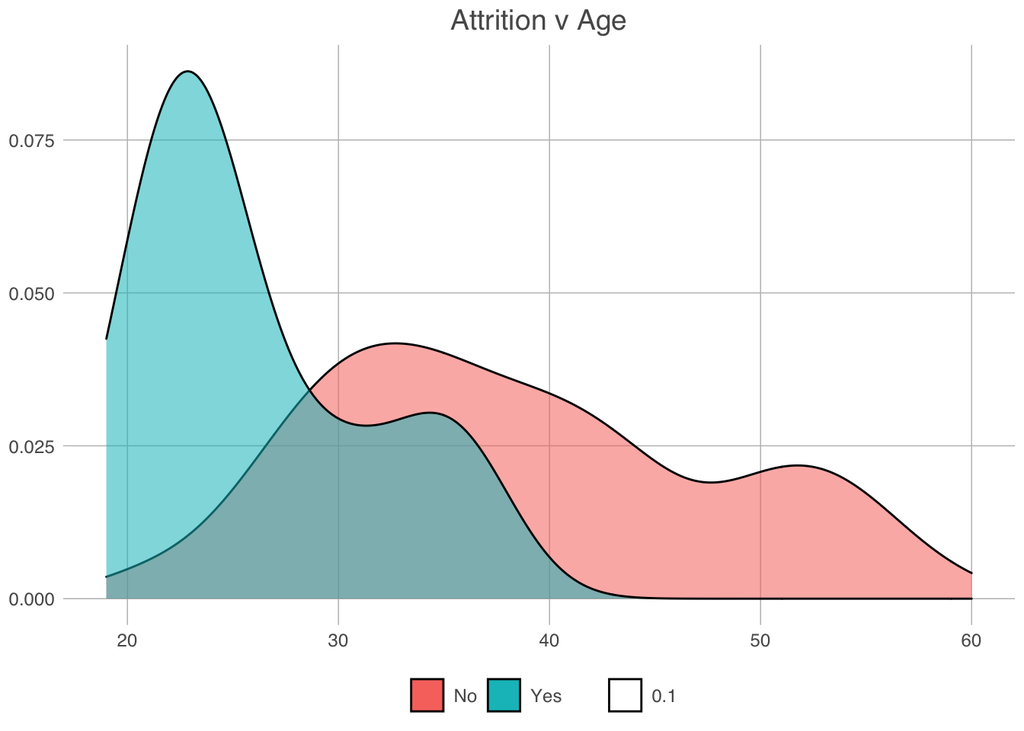

```r
CompSetResult %>% ggplot() + geom_density(aes(x = Age, fill = Attrition, alpha = .1)) +
  theme_excel_new() + ggtitle("Attrition v Age") + ylab("Attrition") + xlab("Age")
```

```r
#CompSetResult %>% ggplot() + geom_bar(aes(x = Age, fill = Attrition), position = "fill", alpha = .7) + coord_flip()

#CompSetResult %>% ggplot() + geom_bar(aes(x = WorkLifeBalance, fill = Attrition), position = "fill", alpha = .7) + coord_flip()
```

### Write CSV of fitted CompSet Data Set

```r
write_csv(CompSetResult, "/Users/olusho/Documents/CaseStudy2DDS\\CCase2Predictions  AttritionOnalaja.csv")
```

# Salary set analysis

```r
SalarySet <- read.csv("CaseStudy2CompSet No Salary.csv", header = TRUE, strip.white=TRUE)
head(SalarySet)
```

```
##    ID Age Attrition    BusinessTravel DailyRate             Department
## 1 871  43        No Travel_Frequently      1422                  Sales
## 2 872  33        No     Travel_Rarely       461 Research & Development
## 3 873  55       Yes     Travel_Rarely       267                  Sales
## 4 874  36        No        Non-Travel      1351 Research & Development
## 5 875  27        No     Travel_Rarely      1302 Research & Development
## 6 876  39       Yes     Travel_Rarely       895                  Sales
##   DistanceFromHome Education   EducationField EmployeeCount EmployeeNumber
## 1                2         4    Life Sciences             1           1849
## 2               13         1    Life Sciences             1            995
## 3               13         4        Marketing             1           1372
## 4                9         4    Life Sciences             1           1949
## 5               19         3            Other             1           1619
## 6                5         3 Technical Degree             1             42
##   EnvironmentSatisfaction Gender HourlyRate JobInvolvement JobLevel
```

[output cut: 41 more lines]

```r
#Work Life Balance, Years in Current Role, Age
Salary <- select(SalarySet, c("ID", "WorkLifeBalance", "YearsInCurrentRole", "Age"))

SalaryEst <- data.frame(knn(traindfTrain[,c(8,1,3)], Salary[,c(2,3,4)], traindfTrain$MonthlyIncome, prob = TRUE, k = 19))

#Join the original table and the competition set
SalSetResult <- cbind(Salary, SalaryEst)

#Set Column name for Attrition
colnames(SalSetResult)[5] <- "Salary"

write_csv(SalSetResult, "/Users/olusho/Documents/CaseStudy2DDS\\CCase2Predictions  SalaryOnalaja.csv")

#RMSE

set.seed(3)
splitPerc = .8

DimSalary = sample(1:dim(SalSetResult)[1], round(splitPerc * dim(SalSetResult)[1]))
trainSalary = SalSetResult[DimSalary,]
testSalary = SalSetResult[-DimSalary,]

a = as.numeric(SalSetResult$Salary)
SalaryModel = lm(a ~ WorkLifeBalance + YearsInCurrentRole + Age, data = SalSetResult)
summary(SalaryModel)
```

```
##
## Call:
## lm(formula = a ~ WorkLifeBalance + YearsInCurrentRole + Age,
##     data = SalSetResult)
##
## Residuals:
##     Min      1Q  Median      3Q     Max
## -92.366 -58.990  -3.738  45.610 307.546
##
## Coefficients:
##                    Estimate Std. Error t value Pr(>|t|)
## (Intercept)         27.0025    22.1284   1.220   0.2233
## WorkLifeBalance      6.1320     5.4625   1.123   0.2625
## YearsInCurrentRole   1.6753     1.0796   1.552   0.1218
## Age                  0.7573     0.4326   1.751   0.0811 .
## ---
## Signif. codes:  0 '***' 0.001 '**' 0.01 '*' 0.05 '.' 0.1 ' ' 1
##
## Residual standard error: 66.56 on 296 degrees of freedom
## Multiple R-squared:  0.02718,    Adjusted R-squared:  0.01732
## F-statistic: 2.757 on 3 and 296 DF,  p-value: 0.04263
```

```r
PredSalaryModel = predict(SalaryModel, newdata = testSalary)

b = as.numeric(testSalary$Salary)

RSME1 = sqrt(mean((b - PredSalaryModel)^2))
```

# Conclusion

Using the variable WorkLifeBalance, YearsInCurrentRole, Age, I created a model to predict the employee attrition rate at an accuracy of 85%. During the data exploration i discover some of the variables are highly correlated and so i decided to elimate such variables as they tend to tell the same stories. I see that people with low job involvement rating seems to have high attrition rate, It also seems the lower the monthly income the higher the attrition rate, i also visualise that people with the age of 19 to 25 has a higher attrition rate. I also explore the job role and as expected i see that managers and research director has the highest job level rating while laboratory technician and reseach scientist has the highest percentage in low job ratings, I also see that managers have being at the company for longer year than any other job role, they also have the highest percentage of older people while sales representatives shows the lowest in these two instances.

This write is supplemented by a video presentation, with the link below;

https://youtu.be/dTKI104rQM0